# 467hw1

## 1 Description

### Course STAT467 Multivariate Analysis

#### Semester Fall 2017

#### Content Assignment 1: Finding MLE of μ and Σ in BVN distribution with (numerical) gradient decsent

## 2 Preliminaries

$$ If \ X \sim N_p(\mu, \Sigma) \ then \\$$ $$f(x;\mu,\Sigma) = \frac{1}{2\pi^{(p/2)} |\Sigma|^{1/2}}e^{{-0.5(x-\mu)'\Sigma^{-1}(x-\mu)}}$$

To use this function and sampling from X, i will load *mvtnorm* library:

```r
library(mvtnorm)
```

We will use 2-dimentional normal distribution(BVN):

$$ If \ X \sim N_2(\mu, \Sigma) \ then \\$$ $$f(x;\mu,\Sigma) = \frac{1}{2\pi |\Sigma|^{1/2}}e^{{-0.5(x-\mu)'\Sigma^{-1}(x-\mu)}}$$

```r
rBVN = function(M, V, cor = 0, seed = 108){

    #M = (vector of size 2) Mean of BVN
    #V = (vector of size 2) Variance of BVN
    #cor = (scaler between 0 and 1) Correlation coefficient of X1 and X2
    #seed = (scaler) random seed

    M = matrix(M, 2, 1)
    s11 = V[1]
    s22 = V[2]
    s12 = cor*sqrt(s11*s22)
    S = matrix(c(s11, s12, s12, s22), 2, 2)

    function(n){

        #n = (scaler integer) sample size

        set.seed(seed)

        return(rmvnorm(n = n, mean = M, sigma = S))
    }
}
```

Using closure, i will fix mean, variance and correlation. For every iteration, only sample size will change. Therefore i will sample from:

$$X \sim N_2(\mu, \Sigma) \ where; \\ $$ $$\mu=\left[ {\begin{array}{c} 0\\ 0\\ \end{array} } \right]\space , \space\space \Sigma=\left[ {\begin{array}{cc} 16 & 5 \\ 5 & 25 \\ \end{array} } \right]$$

I will always use this function for random sampling:

```r
rBVN_fixed = rBVN(M = c(0, 0), V = c(16, 25), cor = 0.25)
```

## 3 Likelihood Function

We know if $ X_i \sim iid \ N_2(\mu, \Sigma)$ then;

$$ L(X; \mu, \Sigma) = \prod{f(x_i; \mu, \Sigma) } $$

To find MLE of $\mu$ and $\Sigma$ we need to find;

$$ \widehat{\mu} = argmax \ L(X; \mu, \Sigma) \ w.r.t. \ \mu \\$$ $$ \widehat{\Sigma} = argmax \ L(X; \mu, \Sigma) \ w.r.t. \ \Sigma $$

We are going to directly implement Log-Leklihood as a function:

```r
Lik_BVN = function(X){

  # X = (matrix of size n x 2) sampled data
  n = dim(X)[1]
  x_bar = colMeans(X)

  function(Theta){


    M = matrix(Theta[1:2], 2, 1)
    S = matrix(Theta[c(3, 5, 5, 4)], 2, 2)
    Sinv = solve(S)

    temp = matrix(0, 2, 2)

    for(i in 1:n){
      temp = temp + (X[i, ] - x_bar) %*% t(X[i, ] - x_bar)
    }

    A = -n*log(2*pi) - (n/2)*log(det(S))

    B = Sinv%*%temp

    C = n*(t(x_bar - M) %*% Sinv %*% (x_bar - M))


    result = A-0.5*(sum(diag(B)) + C)

    return(result)

  }
}
```

## 3 Calculating Numerical Gradient

We are going differentiate and find the Gradient by implementing the limit definition of derivative.

$$ f'(x) = \lim_{h \to 0} \frac{f(x+h) - f(x-h)}{2h}$$

Here is the numerical gradient function:

```r
NG = function(f, x, epsilon = 1e-4){

    # f (function) function of interest
    # x (vector or scaler) f'(x) point of gradient
    # epsilon (scaler) small constant

    n = length(x)

    GradX = numeric()

    for(i in 1:n){

        h = rep(0, n)
        h[i] = epsilon

        x1 = x + h
        x0 = x - h

        GradX[i] =  (f(x1) - f(x0))/(2*epsilon)
    }
    return(GradX)
}
```

Derivative of univariate function:

```r
f1 = function(x) x^2
NG(f1, 3)
```

6.00000000001266

Derivative of bivariate function:

```r
f2 = function(x) x[1]^2 + x[2]^3 +2*x[1]*x[2]
NG(f2, c(2,5))
```

1. 14.0000000000384

2. 79.000000009728

## 4 Optimization with Numerical Gradient Decsent

```r
NGD = function(f, Theta, lr = 10e-5, iter = 100, dec = 3){

    # f = function to be maximized
    # initial = (vector) initial points for the function
    # lr = (float) learning rate
    # iter = (integer) iteration number
    # dec = (integer) number of significant decimals for zero value of gradient

    LIK = numeric(0)
    Theta_M = Theta

    ptm <- proc.time()

    for(i in 1:iter){

        GradTheta = NG(f, Theta)
        Theta = Theta + lr*GradTheta
        Theta_M = rbind(Theta_M, Theta)
        LIK[i] = f(Theta)

        if(round(max(abs(GradTheta)), dec) == 0){


            print(paste("iteration has ended at step", i))
            print(paste("Elapsed Time is", (proc.time() - ptm)[3], "seconds"))

            return(list(Likelihood = LIK, Theta = Theta_M))

        }
    }

    print(paste("Elapsed Time is", (proc.time() - ptm)[3], "seconds"))

    return(list(Likelihood = LIK, Theta = Theta_M))
}
```

```r
Theta = c(0, 0, 16, 25, 5) #we will start iteration from population parameters
```

```r
n = 10 #sample size
X = rBVN_fixed(n) #random sample of size 10
Lik_BVN_fixed = Lik_BVN(X)
result = NGD(Lik_BVN_fixed, Theta, lr = 0.5, iter = 10000)
```

```
[1] "iteration has ended at step 688"
[1] "Elapsed Time is 3.99 seconds"
```

```r
print(result$Theta[dim(result$Theta)[1], ])
```

```
[1]  0.1663862  0.9265646  4.0743886 14.4308860  0.3386321
```

Here is the MLE:

```r
x_bar = colMeans(X) # 2 x 1 vector of M1 and M2
cov = as.vector(cov(X))[c(1,4,2)] # 3 x 1 vector of Sigma1, Sigma2 and Sigma12
theta_MLE = c(x_bar, cov*((n-1)/n))
print(theta_MLE)
```

```
[1]  0.1663862  0.9265646  4.0743723 14.4103883  0.3380721
```

```r
n = 100 #sample size
X = rBVN_fixed(n) #random sample of size 100
Lik_BVN_fixed = Lik_BVN(X)
result2 = NGD(Lik_BVN_fixed, Theta, lr = 0.1, iter = 10000)
```

```
[1] "iteration has ended at step 644"
[1] "Elapsed Time is 18.514 seconds"
```

```r
n = 1000 #sample size
X = rBVN_fixed(n) #random sample of size 1000
Lik_BVN_fixed = Lik_BVN(X)
result3 = NGD(Lik_BVN_fixed, Theta, lr = 0.01, iter = 10000)
```

```
[1] "iteration has ended at step 925"
[1] "Elapsed Time is 223.511 seconds"
```

## 5 Results

Here is the convergence behavior of Log-Likelihood function with respect to sample size. One can see that, at same starting point, number of iterations x step size(learning rate) decrease by sample size. This is expected, because in our algorithm, for initial point we select the population $\theta$ for all samples. And we know when sample size increases, behavior of sample converges to population. Clearly, we could conclude that if we select a sample size n, where n is a very large number, iterations would end up at first steps. However, one could mind the time complexity.

```r
plot_lik = function(Lik, lr, color, tit){
  df = data.frame( x = (1:length(Lik))*lr, LogLik = Lik)
  ggplot(df, aes(x=x, y=LogLik))+geom_point(color = color)+ggtitle(tit)+xlab("iterations x step size")
}
```

```r
library(ggplot2)
```

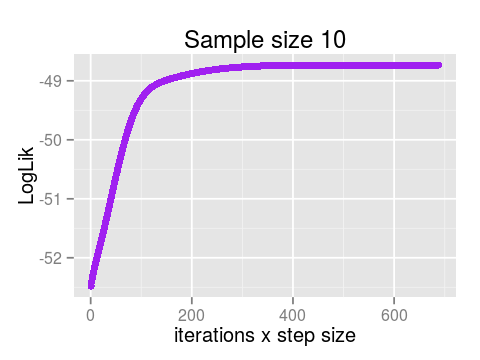

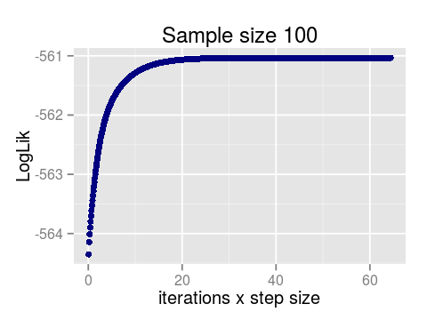

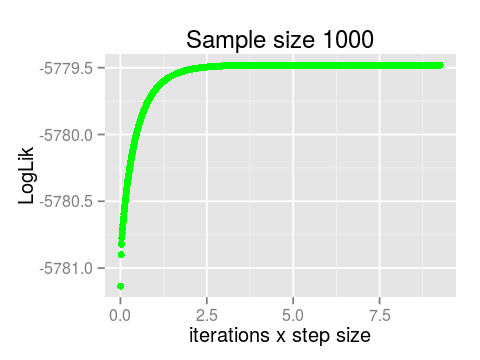

```r
plot_lik(result$Likelihood, lr = 1, "purple", "Sample size 10")
plot_lik(result2$Likelihood, lr = 0.1, "navyblue", "Sample size 100")
plot_lik(result3$Likelihood, lr = 0.01, "green", "Sample size 1000")
```

Convergence of Means through the iterations:

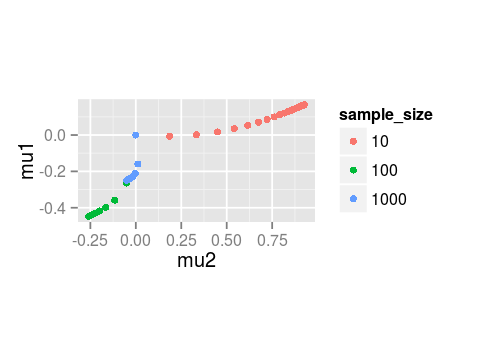

```r
calc_last = function(x){

  n = dim(x)[1]
  max1 = which(round(x[,1], 5) == round(x[n,1], 5))[1]
  max2 = which(round(x[,2], 5) == round(x[n,2], 5))[1]
  max(max1, max2)
}

calc_mus = function(mus, name){

  n = calc_last(mus)
  mus = mus[1:n,]
  rownames(mus) = NULL
  name = rep(name, n)
  mus = data.frame(name, mus)
  colnames(mus) = c("sample_size", "mu1", "mu2")
  return(mus)
}

mus1 = calc_mus(result$Theta[,1:2], "10")
mus2 = calc_mus(result2$Theta[,1:2], "100")
mus3 = calc_mus(result3$Theta[,1:2], "1000")

mus = rbind(rbind(mus1, mus2), mus3)

ggplot(mus, aes(mu2, mu1)) + geom_point(aes(colour = sample_size), size=2)  + coord_fixed(ratio = 1)
```

We know that our iterations would end up at sample mean, but the spatial distance of the sample means are different with respect to their sample sizes. It is clear that spatial distance of sample means decreases with sample size. This could be explained by Law of Large Numbers. When sample size increases sample mean converges to population means.